# Data analysis with Python

Natàlia Padilla & Laura Pérez

## An overview

- What is data analysis?
- The tools
  - Jupyter Notebook
  - Pandas
  - Plotly
- Hands on

## What do you need?

- 💻 Laptop
- 🌍 Internet connection
- 📂 Repository: https://github.com/pyladies-bcn/data-analysis-python/
- 🐍 Python 3
  - Jupyter Notebook
  - Pandas
  - Plotly

## Installation

**Option 1: Anaconda**

Anaconda is a distribution of a bunch of awesome scientific Python tools. You can downloaded from here:

```
https://store.continuum.io/cshop/anaconda/
```

**Option 2: pip**

If you are more a fan of the terminal, you can do pip install:

```
pip install jupyter pandas plotly
```

# What is Data Analysis?

[figure not shown]

# Why Python for Data Analysis?

[figure not shown]

# The tools

[figure not shown]

# Jupyter Notebook

[figure not shown]

# Text Cells

### Header

*italics*, **bold**, **both**

html [link](https://github.com/adam-p/markdown-here/wiki/Markdown-Here-Cheatsheet)

```
def function(input):
    return output
```

1. Ordered List
- Unordered list

| Markdown | is | fun! |
| --- | --- | --- |
| Hello | world | ! |
| 1 | 2 | 3 |

# Code Cells

```python
print('Hello World!')
```

```
Hello World!
```

# Jupyter Output

- Notebook (.ipynb)
- Executable Script (.py)
- HTML (.html)
- Reveal.js slides (.html)

# Jupyter Keyboard Shortcuts

- **`Esc`** will take you into command mode where you can navigate around your notebook with arrow keys.
- While in command mode:
  - **`M`** to change the current cell to Markdown, `Y` to change it back to code
  - **`A`** to insert a new cell above the current cell, `B` to insert a new cell below.
  - **`X`** to delete the current cell
  - **`Z`** to undo cell operation
- **`Enter`** will take you from command mode back into edit mode for the given cell.

# IPython Magic Commands

**%who** list all variables of global scope

**%%time cell** will give you information about a single run of the code in your cell.  
**%%timeit statement** runs the statement 100,000 times and provides the mean of the fastest three times.

**%%writefile file** magic saves the contents of that cell to an external file  
**%pycat file** shows you in a popup the syntax highlighted contents of an external file.

**%run script.py** execute python code from notebook or script

**%%python2** run other kernel (python2, bash, ruby, perl, ...)

**%matplotlib inline** show matplotlib plots in the notebook (like pandas)

# Run R in a Python Notebook

```python
import pandas as pd
movies=pd.read_csv('data/movies.csv')
```

```python
%load_ext rpy2.ipython
```

```python
%R require(ggplot2)
```

```
array([1], dtype=int32)
```

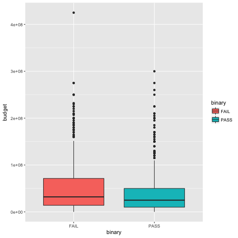

```python
%%R -i movies
ggplot(data = movies,aes(x=binary, y=budget, fill=binary)) + geom_boxplot()
```

# Jupyter-contrib extensions

- SpellChecker
- Table of contents
- Collapsible Headings
- Highlighter

`pip install jupyter_contrib_nbextensions`

# Hands on 💻

1. Open jupyter notebook
2. Create a notebook
3. Add a name
4. Create a text cell
5. Create a code cell
6. Explore jupyter notebook!

# [The Bechdel Test](https://data.world/carolee/women-in-movies)

[figure not shown]

# [The Gender Pay Gap](https://data.oecd.org/earnwage/gender-wage-gap.htm)

[figure not shown]

# Pandas

```python
movies
```

|  | year | imdb | title | test | clean_test | binary | budget | domgross | intgross | code | budget_2013$ | domgross_2013$ | intgross_2013$ | period code | decade code |
| --- | --- | --- | --- | --- | --- | --- | --- | --- | --- | --- | --- | --- | --- | --- | --- |
| 0 | 2013 | tt1711425 | 21 &amp; Over | notalk | notalk | FAIL | 13000000 | 25682380.0 | 42195766.0 | 2013FAIL | 13000000 | 25682380.0 | 42195766.0 | 1.0 | 1.0 |
| 1 | 2012 | tt1343727 | Dredd 3D | ok-disagree | ok | PASS | 45000000 | 13414714.0 | 40868994.0 | 2012PASS | 45658735 | 13611086.0 | 41467257.0 | 1.0 | 1.0 |
| 2 | 2013 | tt2024544 | 12 Years a Slave | notalk-disagree | notalk | FAIL | 20000000 | 53107035.0 | 158607035.0 | 2013FAIL | 20000000 | 53107035.0 | 158607035.0 | 1.0 | 1.0 |
| 3 | 2013 | tt1272878 | 2 Guns | notalk | notalk | FAIL | 61000000 | 75612460.0 | 132493015.0 | 2013FAIL | 61000000 | 75612460.0 | 132493015.0 | 1.0 | 1.0 |
| ... | ... | ... | ... | ... | ... | ... | ... | ... | ... | ... | ... | ... | ... | ... | ... |
| 1790 | 1971 | tt0067800 | Straw Dogs | notalk | notalk | FAIL | 25000000 | 10324441.0 | 11253821.0 | 1971FAIL | 143862856 | 59412143.0 | 64760273.0 | NaN | NaN |
| 1791 | 1971 | tt0067116 | The French Connection | notalk | notalk | FAIL | 2200000 | 41158757.0 | 41158757.0 | 1971FAIL | 12659931 | 236848653.0 | 236848653.0 | NaN | NaN |
| 1792 | 1971 | tt0067992 | Willy Wonka &amp; the Chocolate Factory | men-disagree | men | FAIL | 3000000 | 4000000.0 | 4000000.0 | 1971FAIL | 17263543 | 23018057.0 | 23018057.0 | NaN | NaN |
| 1793 | 1970 | tt0065466 | Beyond the Valley of the Dolls | ok | ok | PASS | 1000000 | 9000000.0 | 9000000.0 | 1970PASS | 5997631 | 53978683.0 | 53978683.0 | NaN | NaN |

1794 rows × 15 columns

# Data Structures

## Series

```python
series_numbers = pd.Series([1,2,3])
series_numbers
```

```
0    1
1    2
2    3
dtype: int64
```

```python
series_words = pd.Series(['pandas','is','fun'])
series_words
```

```
0    pandas
1        is
2       fun
dtype: object
```

## DataFrame

```python
combine_series = pd.DataFrame({'numbers':series_numbers,'words':series_words})
combine_series
```

|  | numbers | words |
| --- | --- | --- |
| 0 | 1 | pandas |
| 1 | 2 | is |
| 2 | 3 | fun |

```python
combine_series.dtypes
```

```
numbers     int64
words      object
dtype: object
```

# File I/O

## Import data

```python
movies=pd.read_csv('data/movies.csv')
movies
```

|  | year | imdb | title | test | clean_test | binary | budget | domgross | intgross | code | budget_2013$ | domgross_2013$ | intgross_2013$ | period code | decade code |
| --- | --- | --- | --- | --- | --- | --- | --- | --- | --- | --- | --- | --- | --- | --- | --- |
| 0 | 2013 | tt1711425 | 21 &amp; Over | notalk | notalk | FAIL | 13000000 | 25682380.0 | 42195766.0 | 2013FAIL | 13000000 | 25682380.0 | 42195766.0 | 1.0 | 1.0 |
| 1 | 2012 | tt1343727 | Dredd 3D | ok-disagree | ok | PASS | 45000000 | 13414714.0 | 40868994.0 | 2012PASS | 45658735 | 13611086.0 | 41467257.0 | 1.0 | 1.0 |
| 2 | 2013 | tt2024544 | 12 Years a Slave | notalk-disagree | notalk | FAIL | 20000000 | 53107035.0 | 158607035.0 | 2013FAIL | 20000000 | 53107035.0 | 158607035.0 | 1.0 | 1.0 |
| 3 | 2013 | tt1272878 | 2 Guns | notalk | notalk | FAIL | 61000000 | 75612460.0 | 132493015.0 | 2013FAIL | 61000000 | 75612460.0 | 132493015.0 | 1.0 | 1.0 |
| ... | ... | ... | ... | ... | ... | ... | ... | ... | ... | ... | ... | ... | ... | ... | ... |
| 1790 | 1971 | tt0067800 | Straw Dogs | notalk | notalk | FAIL | 25000000 | 10324441.0 | 11253821.0 | 1971FAIL | 143862856 | 59412143.0 | 64760273.0 | NaN | NaN |
| 1791 | 1971 | tt0067116 | The French Connection | notalk | notalk | FAIL | 2200000 | 41158757.0 | 41158757.0 | 1971FAIL | 12659931 | 236848653.0 | 236848653.0 | NaN | NaN |
| 1792 | 1971 | tt0067992 | Willy Wonka &amp; the Chocolate Factory | men-disagree | men | FAIL | 3000000 | 4000000.0 | 4000000.0 | 1971FAIL | 17263543 | 23018057.0 | 23018057.0 | NaN | NaN |
| 1793 | 1970 | tt0065466 | Beyond the Valley of the Dolls | ok | ok | PASS | 1000000 | 9000000.0 | 9000000.0 | 1970PASS | 5997631 | 53978683.0 | 53978683.0 | NaN | NaN |

1794 rows × 15 columns

## Export data

```python
movies.to_excel('output/movies.xlsx')
```

# Exploring the data

## DataFrame dimensions

```python
movies.shape
```

```
(1794, 15)
```

## Column names

```python
movies.columns
```

```
Index(['year', 'imdb', 'title', 'test', 'clean_test', 'binary', 'budget',
       'domgross', 'intgross', 'code', 'budget_2013$', 'domgross_2013$',
       'intgross_2013$', 'period code', 'decade code'],
      dtype='object')
```

## DataFrame overview

```python
movies.head()
```

|  | year | imdb | title | test | clean_test | binary | budget | domgross | intgross | code | budget_2013$ | domgross_2013$ | intgross_2013$ | period code | decade code |
| --- | --- | --- | --- | --- | --- | --- | --- | --- | --- | --- | --- | --- | --- | --- | --- |
| 0 | 2013 | tt1711425 | 21 &amp; Over | notalk | notalk | FAIL | 13000000 | 25682380.0 | 42195766.0 | 2013FAIL | 13000000 | 25682380.0 | 42195766.0 | 1.0 | 1.0 |
| 1 | 2012 | tt1343727 | Dredd 3D | ok-disagree | ok | PASS | 45000000 | 13414714.0 | 40868994.0 | 2012PASS | 45658735 | 13611086.0 | 41467257.0 | 1.0 | 1.0 |
| 2 | 2013 | tt2024544 | 12 Years a Slave | notalk-disagree | notalk | FAIL | 20000000 | 53107035.0 | 158607035.0 | 2013FAIL | 20000000 | 53107035.0 | 158607035.0 | 1.0 | 1.0 |
| 3 | 2013 | tt1272878 | 2 Guns | notalk | notalk | FAIL | 61000000 | 75612460.0 | 132493015.0 | 2013FAIL | 61000000 | 75612460.0 | 132493015.0 | 1.0 | 1.0 |
| 4 | 2013 | tt0453562 | 42 | men | men | FAIL | 40000000 | 95020213.0 | 95020213.0 | 2013FAIL | 40000000 | 95020213.0 | 95020213.0 | 1.0 | 1.0 |

## Statistics of numerical columns

```python
movies.describe()
```

|  | year | budget | domgross | intgross | budget_2013$ | domgross_2013$ | intgross_2013$ | period code | decade code |
| --- | --- | --- | --- | --- | --- | --- | --- | --- | --- |
| count | 1794.000000 | 1.794000e+03 | 1.777000e+03 | 1.783000e+03 | 1.794000e+03 | 1.776000e+03 | 1.783000e+03 | 1615.000000 | 1615.000000 |
| mean | 2002.552397 | 4.482646e+07 | 6.913205e+07 | 1.503857e+08 | 5.546461e+07 | 9.517478e+07 | 1.978380e+08 | 2.419814 | 1.937461 |
| std | 8.979731 | 4.818603e+07 | 8.036731e+07 | 2.103353e+08 | 5.491864e+07 | 1.259653e+08 | 2.835079e+08 | 1.194620 | 0.690116 |
| min | 1970.000000 | 7.000000e+03 | 0.000000e+00 | 8.280000e+02 | 8.632000e+03 | 8.990000e+02 | 8.990000e+02 | 1.000000 | 1.000000 |
| 25% | 1998.000000 | 1.200000e+07 | 1.631157e+07 | 2.612947e+07 | 1.606892e+07 | 2.054659e+07 | 3.323260e+07 | 1.000000 | 1.000000 |
| 50% | 2005.000000 | 2.800000e+07 | 4.219406e+07 | 7.648246e+07 | 3.699579e+07 | 5.599364e+07 | 9.623964e+07 | 2.000000 | 2.000000 |
| 75% | 2009.000000 | 6.000000e+07 | 9.335492e+07 | 1.898509e+08 | 7.833790e+07 | 1.216784e+08 | 2.414790e+08 | 3.000000 | 2.000000 |
| max | 2013.000000 | 4.250000e+08 | 7.605076e+08 | 2.783919e+09 | 4.614359e+08 | 1.771683e+09 | 3.171931e+09 | 5.000000 | 3.000000 |

## Statistics of categorical columns

```python
movies.clean_test.value_counts()
```

```
ok         803
notalk     514
men        194
dubious    142
nowomen    141
Name: clean_test, dtype: int64
```

# Selecting columns and rows

## Select a column

```python
movies.year
```

```
0       2013
1       2012
2       2013
3       2013
        ...
1790    1971
1791    1971
1792    1971
1793    1970
Name: year, Length: 1794, dtype: int64
```

```python
movies['year']
```

```
0       2013
1       2012
2       2013
3       2013
        ...
1790    1971
1791    1971
1792    1971
1793    1970
Name: year, Length: 1794, dtype: int64
```

## Select by position

```python
movies[2:5]
```

|  | year | imdb | title | test | clean_test | binary | budget | domgross | intgross | code | budget_2013$ | domgross_2013$ | intgross_2013$ | period code | decade code |
| --- | --- | --- | --- | --- | --- | --- | --- | --- | --- | --- | --- | --- | --- | --- | --- |
| 2 | 2013 | tt2024544 | 12 Years a Slave | notalk-disagree | notalk | FAIL | 20000000 | 53107035.0 | 158607035.0 | 2013FAIL | 20000000 | 53107035.0 | 158607035.0 | 1.0 | 1.0 |
| 3 | 2013 | tt1272878 | 2 Guns | notalk | notalk | FAIL | 61000000 | 75612460.0 | 132493015.0 | 2013FAIL | 61000000 | 75612460.0 | 132493015.0 | 1.0 | 1.0 |
| 4 | 2013 | tt0453562 | 42 | men | men | FAIL | 40000000 | 95020213.0 | 95020213.0 | 2013FAIL | 40000000 | 95020213.0 | 95020213.0 | 1.0 | 1.0 |

```python
movies.loc[2:4,['test','clean_test']]
```

|  | test | clean_test |
| --- | --- | --- |
| 2 | notalk-disagree | notalk |
| 3 | notalk | notalk |
| 4 | men | men |

## Selection by boolean

```python
movies[(movies.year>2000)&(movies.test=='ok')]
```

|  | year | imdb | title | test | clean_test | binary | budget | domgross | intgross | code | budget_2013$ | domgross_2013$ | intgross_2013$ | period code | decade code |
| --- | --- | --- | --- | --- | --- | --- | --- | --- | --- | --- | --- | --- | --- | --- | --- |
| 8 | 2013 | tt1814621 | Admission | ok | ok | PASS | 13000000 | 18007317.0 | 18007317.0 | 2013PASS | 13000000 | 18007317.0 | 18007317.0 | 1.0 | 1.0 |
| 11 | 2013 | tt1322269 | August: Osage County | ok | ok | PASS | 25000000 | 37304874.0 | 50304874.0 | 2013PASS | 25000000 | 37304874.0 | 50304874.0 | 1.0 | 1.0 |
| 12 | 2013 | tt1559547 | Beautiful Creatures | ok | ok | PASS | 50000000 | 19452138.0 | 55940671.0 | 2013PASS | 50000000 | 19452138.0 | 55940671.0 | 1.0 | 1.0 |
| 15 | 2013 | tt1939659 | Carrie | ok | ok | PASS | 30000000 | 35266619.0 | 85001659.0 | 2013PASS | 30000000 | 35266619.0 | 85001659.0 | 1.0 | 1.0 |
| ... | ... | ... | ... | ... | ... | ... | ... | ... | ... | ... | ... | ... | ... | ... | ... |
| 1206 | 2001 | tt0230600 | The Others | ok | ok | PASS | 17000000 | 96522687.0 | 209947037.0 | 2001PASS | 22369381 | 127008987.0 | 276257960.0 | 3.0 | 2.0 |
| 1207 | 2001 | tt0247638 | The Princess Diaries | ok | ok | PASS | 30000000 | 108244774.0 | 165334774.0 | 2001PASS | 39475379 | 142433448.0 | 217555094.0 | 3.0 | 2.0 |
| 1208 | 2001 | tt0265666 | The Royal Tenenbaums | ok | ok | PASS | 28000000 | 52353636.0 | 71430876.0 | 2001PASS | 36843687 | 68889320.0 | 93992029.0 | 3.0 | 2.0 |
| 1209 | 2001 | tt0209475 | The Wedding Planner | ok | ok | PASS | 28000000 | 60400856.0 | 94728529.0 | 2001PASS | 36843687 | 79478222.0 | 124648152.0 | 3.0 | 2.0 |

490 rows × 15 columns

## Selection by callable

```python
movies[lambda x: x.year+1>2005]
```

|  | year | imdb | title | test | clean_test | binary | budget | domgross | intgross | code | budget_2013$ | domgross_2013$ | intgross_2013$ | period code | decade code |
| --- | --- | --- | --- | --- | --- | --- | --- | --- | --- | --- | --- | --- | --- | --- | --- |
| 0 | 2013 | tt1711425 | 21 &amp; Over | notalk | notalk | FAIL | 13000000 | 25682380.0 | 42195766.0 | 2013FAIL | 13000000 | 25682380.0 | 42195766.0 | 1.0 | 1.0 |
| 1 | 2012 | tt1343727 | Dredd 3D | ok-disagree | ok | PASS | 45000000 | 13414714.0 | 40868994.0 | 2012PASS | 45658735 | 13611086.0 | 41467257.0 | 1.0 | 1.0 |
| 2 | 2013 | tt2024544 | 12 Years a Slave | notalk-disagree | notalk | FAIL | 20000000 | 53107035.0 | 158607035.0 | 2013FAIL | 20000000 | 53107035.0 | 158607035.0 | 1.0 | 1.0 |
| 3 | 2013 | tt1272878 | 2 Guns | notalk | notalk | FAIL | 61000000 | 75612460.0 | 132493015.0 | 2013FAIL | 61000000 | 75612460.0 | 132493015.0 | 1.0 | 1.0 |
| ... | ... | ... | ... | ... | ... | ... | ... | ... | ... | ... | ... | ... | ... | ... | ... |
| 922 | 2005 | tt0240200 | Water | ok | ok | PASS | 3000000 | 5529144.0 | 8119205.0 | 2005PASS | 3579099 | 6596452.0 | 9686481.0 | 2.0 | 2.0 |
| 923 | 2005 | tt0375210 | White Noise | notalk | notalk | FAIL | 10000000 | 56094360.0 | 92094360.0 | 2005FAIL | 11930331 | 66922430.0 | 109871622.0 | 2.0 | 2.0 |
| 924 | 2005 | tt0443295 | Yours, Mine and Ours | ok | ok | PASS | 45000000 | 53359917.0 | 72359917.0 | 2005PASS | 53686491 | 63660149.0 | 86327778.0 | 2.0 | 2.0 |
| 925 | 2005 | tt0406375 | Zathura: A Space Adventure | nowomen | nowomen | FAIL | 65000000 | 28045540.0 | 58545540.0 | 2005FAIL | 77547153 | 33459258.0 | 69846769.0 | 2.0 | 2.0 |

926 rows × 15 columns

# Operations

## Numerical Operations

```python
movies['intOnly']=movies.intgross - movies.domgross
```

## String Operations

```python
movies['clean_test_formated']=movies.clean_test.replace({
    'ok':'Bechdel test OK',
    'dubious':'Bechdel test dubious',
    'men':'Women only talk about men',
    'notalk':'Women don\'t talk to each other',
    'nowomen':'Less than two women in the movie'
})
```

## Apply Function

```python
movies['budget_euro']=movies.apply(lambda x: x.budget * 0.81109579,axis=1)
```

## Sorting Values

```python
movies.sort_values(by=['year','budget'],ascending=False)[:5]
```

|  | year | imdb | title | test | clean_test | binary | budget | domgross | intgross | code | budget_2013$ | domgross_2013$ | intgross_2013$ | period code | decade code | intOnly | clean_test_formated | budget_euro |
| --- | --- | --- | --- | --- | --- | --- | --- | --- | --- | --- | --- | --- | --- | --- | --- | --- | --- | --- |
| 83 | 2013 | tt1210819 | The Lone Ranger | notalk | notalk | FAIL | 275000000 | 89289910.0 | 2.599899e+08 | 2013FAIL | 275000000 | 89289910.0 | 2.599899e+08 | 1.0 | 1.0 | 170700000.0 | Women don't talk to each other | 2.230513e+08 |
| 77 | 2013 | tt1170358 | The Hobbit: The Desolation of Smaug | notalk-disagree | notalk | FAIL | 250000000 | 257397516.0 | 9.373975e+08 | 2013FAIL | 250000000 | 257397516.0 | 9.373975e+08 | 1.0 | 1.0 | 680000000.0 | Women don't talk to each other | 2.027739e+08 |
| 5 | 2013 | tt1335975 | 47 Ronin | men | men | FAIL | 225000000 | 38362475.0 | 1.458038e+08 | 2013FAIL | 225000000 | 38362475.0 | 1.458038e+08 | 1.0 | 1.0 | 107441367.0 | Women only talk about men | 1.824966e+08 |
| 43 | 2013 | tt0770828 | Man of Steel | ok-disagree | ok | PASS | 225000000 | 291045518.0 | 6.879995e+08 | 2013PASS | 225000000 | 291045518.0 | 6.879995e+08 | 1.0 | 1.0 | 396954000.0 | Bechdel test OK | 1.824966e+08 |
| 36 | 2013 | tt1300854 | Iron Man 3 | dubious-disagree | dubious | FAIL | 200000000 | 408992272.0 | 1.212692e+09 | 2013FAIL | 200000000 | 408992272.0 | 1.212692e+09 | 1.0 | 1.0 | 803700000.0 | Bechdel test dubious | 1.622192e+08 |

## Mark Duplicates

```python
movies[movies.duplicated(subset=['year'],keep=False)]
```

|  | year | imdb | title | test | clean_test | binary | budget | domgross | intgross | code | budget_2013$ | domgross_2013$ | intgross_2013$ | period code | decade code | intOnly | clean_test_formated | budget_euro |
| --- | --- | --- | --- | --- | --- | --- | --- | --- | --- | --- | --- | --- | --- | --- | --- | --- | --- | --- |
| 0 | 2013 | tt1711425 | 21 &amp; Over | notalk | notalk | FAIL | 13000000 | 25682380.0 | 42195766.0 | 2013FAIL | 13000000 | 25682380.0 | 42195766.0 | 1.0 | 1.0 | 16513386.0 | Women don't talk to each other | 1.054425e+07 |
| 1 | 2012 | tt1343727 | Dredd 3D | ok-disagree | ok | PASS | 45000000 | 13414714.0 | 40868994.0 | 2012PASS | 45658735 | 13611086.0 | 41467257.0 | 1.0 | 1.0 | 27454280.0 | Bechdel test OK | 3.649931e+07 |
| 2 | 2013 | tt2024544 | 12 Years a Slave | notalk-disagree | notalk | FAIL | 20000000 | 53107035.0 | 158607035.0 | 2013FAIL | 20000000 | 53107035.0 | 158607035.0 | 1.0 | 1.0 | 105500000.0 | Women don't talk to each other | 1.622192e+07 |
| 3 | 2013 | tt1272878 | 2 Guns | notalk | notalk | FAIL | 61000000 | 75612460.0 | 132493015.0 | 2013FAIL | 61000000 | 75612460.0 | 132493015.0 | 1.0 | 1.0 | 56880555.0 | Women don't talk to each other | 4.947684e+07 |
| ... | ... | ... | ... | ... | ... | ... | ... | ... | ... | ... | ... | ... | ... | ... | ... | ... | ... | ... |
| 1789 | 1971 | tt0067741 | Shaft | notalk | notalk | FAIL | 53012938 | 70327868.0 | 107190108.0 | 1971FAIL | 305063707 | 404702718.0 | 616827003.0 | NaN | NaN | 36862240.0 | Women don't talk to each other | 4.299857e+07 |
| 1790 | 1971 | tt0067800 | Straw Dogs | notalk | notalk | FAIL | 25000000 | 10324441.0 | 11253821.0 | 1971FAIL | 143862856 | 59412143.0 | 64760273.0 | NaN | NaN | 929380.0 | Women don't talk to each other | 2.027739e+07 |
| 1791 | 1971 | tt0067116 | The French Connection | notalk | notalk | FAIL | 2200000 | 41158757.0 | 41158757.0 | 1971FAIL | 12659931 | 236848653.0 | 236848653.0 | NaN | NaN | 0.0 | Women don't talk to each other | 1.784411e+06 |
| 1792 | 1971 | tt0067992 | Willy Wonka &amp; the Chocolate Factory | men-disagree | men | FAIL | 3000000 | 4000000.0 | 4000000.0 | 1971FAIL | 17263543 | 23018057.0 | 23018057.0 | NaN | NaN | 0.0 | Women only talk about men | 2.433287e+06 |

1793 rows × 18 columns

## Drop Duplicates

```python
movies.drop_duplicates(subset=['year'],keep='first')[:5]
```

|  | year | imdb | title | test | clean_test | binary | budget | domgross | intgross | code | budget_2013$ | domgross_2013$ | intgross_2013$ | period code | decade code | intOnly | clean_test_formated | budget_euro |
| --- | --- | --- | --- | --- | --- | --- | --- | --- | --- | --- | --- | --- | --- | --- | --- | --- | --- | --- |
| 0 | 2013 | tt1711425 | 21 &amp; Over | notalk | notalk | FAIL | 13000000 | 25682380.0 | 42195766.0 | 2013FAIL | 13000000 | 25682380.0 | 42195766.0 | 1.0 | 1.0 | 16513386.0 | Women don't talk to each other | 1.054425e+07 |
| 1 | 2012 | tt1343727 | Dredd 3D | ok-disagree | ok | PASS | 45000000 | 13414714.0 | 40868994.0 | 2012PASS | 45658735 | 13611086.0 | 41467257.0 | 1.0 | 1.0 | 27454280.0 | Bechdel test OK | 3.649931e+07 |
| 185 | 2011 | tt1622547 | 30 Minutes or Less | notalk | notalk | FAIL | 28000000 | 37053924.0 | 40966716.0 | 2011FAIL | 28999342 | 38376408.0 | 42428850.0 | 1.0 | 1.0 | 3912792.0 | Women don't talk to each other | 2.271068e+07 |
| 309 | 2010 | tt1542344 | 127 Hours | dubious-disagree | dubious | FAIL | 18000000 | 18335230.0 | 60735230.0 | 2010FAIL | 19228173 | 19586277.0 | 64879307.0 | 1.0 | 1.0 | 42400000.0 | Bechdel test dubious | 1.459972e+07 |
| 438 | 2009 | tt1022603 | (500) Days of Summer | notalk-disagree | notalk | FAIL | 7500000 | 32391374.0 | 60803210.0 | 2009FAIL | 8142987 | 35168338.0 | 66015966.0 | 2.0 | 2.0 | 28411836.0 | Women don't talk to each other | 6.083218e+06 |

## Set Index

```python
movies.set_index(['title'])
```

| title | year | imdb | test | clean_test | binary | budget | domgross | intgross | code | budget_2013$ | domgross_2013$ | intgross_2013$ | period code | decade code | intOnly | clean_test_formated | budget_euro |
| --- | --- | --- | --- | --- | --- | --- | --- | --- | --- | --- | --- | --- | --- | --- | --- | --- | --- |
| 21 &amp; Over | 2013 | tt1711425 | notalk | notalk | FAIL | 13000000 | 25682380.0 | 42195766.0 | 2013FAIL | 13000000 | 25682380.0 | 42195766.0 | 1.0 | 1.0 | 16513386.0 | Women don't talk to each other | 1.054425e+07 |
| Dredd 3D | 2012 | tt1343727 | ok-disagree | ok | PASS | 45000000 | 13414714.0 | 40868994.0 | 2012PASS | 45658735 | 13611086.0 | 41467257.0 | 1.0 | 1.0 | 27454280.0 | Bechdel test OK | 3.649931e+07 |
| 12 Years a Slave | 2013 | tt2024544 | notalk-disagree | notalk | FAIL | 20000000 | 53107035.0 | 158607035.0 | 2013FAIL | 20000000 | 53107035.0 | 158607035.0 | 1.0 | 1.0 | 105500000.0 | Women don't talk to each other | 1.622192e+07 |
| 2 Guns | 2013 | tt1272878 | notalk | notalk | FAIL | 61000000 | 75612460.0 | 132493015.0 | 2013FAIL | 61000000 | 75612460.0 | 132493015.0 | 1.0 | 1.0 | 56880555.0 | Women don't talk to each other | 4.947684e+07 |
| ... | ... | ... | ... | ... | ... | ... | ... | ... | ... | ... | ... | ... | ... | ... | ... | ... | ... |
| Straw Dogs | 1971 | tt0067800 | notalk | notalk | FAIL | 25000000 | 10324441.0 | 11253821.0 | 1971FAIL | 143862856 | 59412143.0 | 64760273.0 | NaN | NaN | 929380.0 | Women don't talk to each other | 2.027739e+07 |
| The French Connection | 1971 | tt0067116 | notalk | notalk | FAIL | 2200000 | 41158757.0 | 41158757.0 | 1971FAIL | 12659931 | 236848653.0 | 236848653.0 | NaN | NaN | 0.0 | Women don't talk to each other | 1.784411e+06 |
| Willy Wonka &amp; the Chocolate Factory | 1971 | tt0067992 | men-disagree | men | FAIL | 3000000 | 4000000.0 | 4000000.0 | 1971FAIL | 17263543 | 23018057.0 | 23018057.0 | NaN | NaN | 0.0 | Women only talk about men | 2.433287e+06 |
| Beyond the Valley of the Dolls | 1970 | tt0065466 | ok | ok | PASS | 1000000 | 9000000.0 | 9000000.0 | 1970PASS | 5997631 | 53978683.0 | 53978683.0 | NaN | NaN | 0.0 | Bechdel test OK | 8.110958e+05 |

1794 rows × 17 columns

# Group data

## Groupby

```python
movies.groupby('year').budget.mean()[:5]
```

```
year
1970    1.000000e+06
1971    1.714259e+07
1972    3.670667e+06
1973    7.195400e+06
1974    4.182857e+06
Name: budget, dtype: float64
```

# Merge DataFrames

```python
movies_kaggle=pd.read_csv('data/tmdb_5000_movies.csv')
```

```python
movies_kaggle[:2]
```

|  | budget | genres | homepage | id | keywords | original_language | original_title | overview | popularity | production_companies | production_countries | release_date | revenue | runtime | spoken_languages | status | tagline | title | vote_average | vote_count |
| --- | --- | --- | --- | --- | --- | --- | --- | --- | --- | --- | --- | --- | --- | --- | --- | --- | --- | --- | --- | --- |
| 0 | 237000000 | [{"id": 28, "name": "Action"}, {"id": 12, "nam... | http://www.avatarmovie.com/ | 19995 | [{"id": 1463, "name": "culture clash"}, {"id":... | en | Avatar | In the 22nd century, a paraplegic Marine is di... | 150.437577 | [{"name": "Ingenious Film Partners", "id": 289... | [{"iso_3166_1": "US", "name": "United States o... | 2009-12-10 | 2787965087 | 162.0 | [{"iso_639_1": "en", "name": "English"}, {"iso... | Released | Enter the World of Pandora. | Avatar | 7.2 | 11800 |
| 1 | 300000000 | [{"id": 12, "name": "Adventure"}, {"id": 14, "... | http://disney.go.com/disneypictures/pirates/ | 285 | [{"id": 270, "name": "ocean"}, {"id": 726, "na... | en | Pirates of the Caribbean: At World's End | Captain Barbossa, long believed to be dead, ha... | 139.082615 | [{"name": "Walt Disney Pictures", "id": 2}, {"... | [{"iso_3166_1": "US", "name": "United States o... | 2007-05-19 | 961000000 | 169.0 | [{"iso_639_1": "en", "name": "English"}] | Released | At the end of the world, the adventure begins. | Pirates of the Caribbean: At World's End | 6.9 | 4500 |

```python
movies=movies.merge(movies_kaggle,how='left',on='title')
```

## Duplicated column names

```python
movies.rename(columns={'budget_x':'budget','budget_y':'budget_kaggle'},inplace=True)
```

## Missing data

```python
len(movies[movies.budget_kaggle.isnull()].title.values)/len(movies)
```

```
0.14858096828046743
```

```python
movies.dropna()
```

|  | year | imdb | title | test | clean_test | binary | budget | domgross | intgross | code | ... | production_companies | production_countries | release_date | revenue | runtime | spoken_languages | status | tagline | vote_average | vote_count |
| --- | --- | --- | --- | --- | --- | --- | --- | --- | --- | --- | --- | --- | --- | --- | --- | --- | --- | --- | --- | --- | --- |
| 3 | 2013 | tt1272878 | 2 Guns | notalk | notalk | FAIL | 61000000 | 75612460.0 | 132493015.0 | 2013FAIL | ... | [{"name": "Universal Studios", "id": 13}, {"na... | [{"iso_3166_1": "US", "name": "United States o... | 2013-08-02 | 131940411.0 | 109.0 | [{"iso_639_1": "es", "name": "Espa\u00f1ol"}, ... | Released | 2 Guns, 1 Bank. | 6.6 | 1589.0 |
| 6 | 2013 | tt1606378 | A Good Day to Die Hard | notalk | notalk | FAIL | 92000000 | 67349198.0 | 304249198.0 | 2013FAIL | ... | [{"name": "Ingenious Media", "id": 290}, {"nam... | [{"iso_3166_1": "US", "name": "United States o... | 2013-02-06 | 304654182.0 | 98.0 | [{"iso_639_1": "en", "name": "English"}, {"iso... | Released | Yippee Ki-Yay Mother Russia | 5.2 | 3493.0 |
| 10 | 2013 | tt1800241 | American Hustle | ok-disagree | ok | PASS | 40000000 | 148430908.0 | 249484909.0 | 2013PASS | ... | [{"name": "Columbia Pictures", "id": 5}, {"nam... | [{"iso_3166_1": "US", "name": "United States o... | 2013-12-12 | 251171807.0 | 138.0 | [{"iso_639_1": "en", "name": "English"}] | Released | Everyone Hustles To Survive | 6.8 | 2807.0 |
| 14 | 2013 | tt1535109 | Captain Phillips | notalk | notalk | FAIL | 55000000 | 107136417.0 | 218743570.0 | 2013FAIL | ... | [{"name": "Columbia Pictures", "id": 5}] | [{"iso_3166_1": "US", "name": "United States o... | 2013-10-10 | 95000000.0 | 134.0 | [{"iso_639_1": "en", "name": "English"}, {"iso... | Released | Out here survival is everything. | 7.6 | 2454.0 |
| ... | ... | ... | ... | ... | ... | ... | ... | ... | ... | ... | ... | ... | ... | ... | ... | ... | ... | ... | ... | ... | ... |
| 1584 | 1992 | tt0104036 | The Crying Game | men | men | FAIL | 4000000 | 62546695.0 | 62546695.0 | 1992FAIL | ... | [{"name": "Miramax Films", "id": 14}, {"name":... | [{"iso_3166_1": "JP", "name": "Japan"}, {"iso_... | 1992-09-02 | 62548947.0 | 112.0 | [{"iso_639_1": "en", "name": "English"}] | Released | Play At Your Own Risk. | 6.9 | 176.0 |
| 1602 | 1990 | tt0099088 | Back to the Future Part III | notalk | notalk | FAIL | 40000000 | 87666629.0 | 243700000.0 | 1990FAIL | ... | [{"name": "Universal Pictures", "id": 33}, {"n... | [{"iso_3166_1": "US", "name": "United States o... | 1990-05-25 | 244527583.0 | 118.0 | [{"iso_639_1": "en", "name": "English"}] | Released | They've saved the best trip for last... But th... | 7.1 | 2900.0 |
| 1610 | 1990 | tt0099785 | Home Alone | men-disagree | men | FAIL | 15000000 | 285761243.0 | 476684675.0 | 1990FAIL | ... | [{"name": "Twentieth Century Fox Film Corporat... | [{"iso_3166_1": "US", "name": "United States o... | 1990-11-09 | 476684675.0 | 103.0 | [{"iso_639_1": "en", "name": "English"}] | Released | A Family Comedy Without the Family. | 7.1 | 2414.0 |
| 1614 | 1990 | tt0099810 | The Hunt for Red October | notalk | notalk | FAIL | 30000000 | 120709866.0 | 200500000.0 | 1990FAIL | ... | [{"name": "Paramount Pictures", "id": 4}, {"na... | [{"iso_3166_1": "US", "name": "United States o... | 1990-03-02 | 199200000.0 | 134.0 | [{"iso_639_1": "en", "name": "English"}, {"iso... | Released | Invisible. Silent. Stolen. | 7.2 | 957.0 |

615 rows × 37 columns

# Hands on 💻

1. Load the Gender Pay Gap (GPG) Dataset
2. How many rows and columns does the dataframe have?
3. Which are these columns?
4. Look at the first 5 rows
5. Can you sort the values by year and GPG value?
6. Select all values of 2013, which is the GPG median?
7. Group GPG value by year, the median increases or decreases?
8. Create a new column which a meaningful unique identifier and make it the index of the dataframe

# Data Analysis

## Descriptive Statistics

```python
movies.groupby('binary').budget.mean()
```

```
binary
FAIL    5.039935e+07
PASS    3.794418e+07
Name: budget, dtype: float64
```

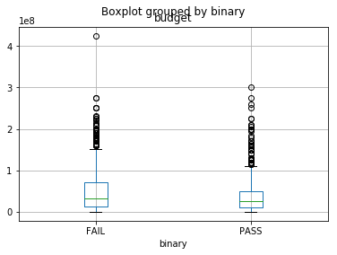

```python
movies.boxplot(column='budget',by='binary')
```

## Inference Statistics

### T-test in Scipy

The movies that pass the test have a different budget from those who don't pass it?

```python
from scipy import stats
```

```python
movies_testPass=movies[movies.clean_test=='ok']
movies_testFail=movies[movies.clean_test!='ok']
```

```python
stats.ttest_ind(movies_testPass.budget.values,movies_testFail.budget.values)
```

```
Ttest_indResult(statistic=-5.4968781562606654, pvalue=4.4199859301620574e-08)
```

### Linear Regression in Scikit-Learn

Is there a relationship between the budget and the revenues?

```python
from sklearn.linear_model import LinearRegression
```

```python
#Drop empty values
df=movies[['budget','intgross']].dropna()
```

```python
#Fit the model
lr = LinearRegression()
lr.fit(df[['budget']],df[['intgross']])
```

```
LinearRegression(copy_X=True, fit_intercept=True, n_jobs=1, normalize=False)
```

```python
#Predict the data
intgross_pred=lr.predict(df[['budget']])
```

```python
#Obtain R2
lr.score(df[['budget']],df[['intgross']])
```

```
0.4961146311119937
```

# Data Visualization

```python
from plotly import offline
import plotly.graph_objs as go

offline.init_notebook_mode()
```

```python
#Boxplot
boxplot_pass=go.Box(x=movies_testPass.binary.values,y=movies_testPass.budget.values,fillcolor='rgba(44, 160, 101, 0.5)',line=dict(color='rgba(44, 160, 101, 0.5)'),showlegend = False)
boxplot_fail=go.Box(x=movies_testFail.binary.values,y=movies_testFail.budget.values,fillcolor='rgba(255, 65, 54, 0.5)',line=dict(color='rgba(255, 65, 54, 0.5)'),showlegend = False)
layout=go.Layout(title="Budget vs Bechdel test ")
data=[boxplot_pass,boxplot_fail]
offline.plot({
    "data": data,
    "layout": layout
},show_link=False,filename='output/boxplot.html');
```

boxplot.html

```python
#Scatterplot
line=lr.coef_*df.budget.values+lr.intercept_
trace_scatter = go.Scatter(
    x=df.budget.values,
    y=df.intgross.values,
    mode='markers',
    marker=go.Marker(color='rgb(255, 127, 14)'),
    name='Data')
trace_line = go.Scatter(
    x=df.budget.values,
    y=line[0],
    mode='lines',
    marker=go.Marker(color='rgb(31, 119, 180)'),
    name='Fit')
annotation = go.Annotation(
    x=400e6,
    y=0.5e9,
    text='R2 = '+str(round(lr.score(df[['budget']],df[['intgross']]),4)),
    showarrow=False,
    font=go.Font(size=16))
layout=go.Layout(
    title="Correlation between Intgross and budget",
    xaxis=dict(title='budget'),
    yaxis=dict(title='intgross'),
    annotations=[annotation])
data = [trace_scatter,trace_line]
offline.plot({
    "data": data,
    "layout": layout,
}, show_link=False,filename='output/scatterplot.html');
```

scatterplot.html

# Hands on 💻

- Movies dataset
- Gender pay gap dataset
- Download a 'Gender Inequality' dataset from :
  - [Kaggle](https://www.kaggle.com)
  - [OECD](https://data.oecd.org)
  - [Global Gender Gap Report 2016](http://reports.weforum.org/global-gender-gap-report-2016/rankings/?doing_wp_cron=1520249369.9271149635314941406250)
  - [Open Data BCN](http://opendata-ajuntament.barcelona.cat)